# Analysis of Melbourne's Living Environment

**10 May 2022 | 02806 Social Data Analysis & Visualization**

**By Emma Valen Rian, Eper Stinner, Aaron Alberg**

*Access our explanation and data sources [here](https://github.com/aaronalberg/social-data-notebook)*

Melbourne is the second largest city in Australia, and its metropolitan area alone is home to more than a million people. (...) In this article we want to take a closer look at how it is to live in central Melbourne by exploring the relationship between wealth, environmental conditions and access to services. Do the rich people in Melbourne have access to more services and a cleaner living environment? And does Melbournes residents care about living next to green spaces? Stay tuned to explore these questions in further detail with us.

Let us first explore the data with some maps. Can we see some patterns between the location (and price) of houses and the proximity of green spaces and public services?

The following map shows an overview of houses sold in the city of Melbourne. We only want to investigate houses within the boundaries of the 14 main suburbs in the municipality of Melbourne, and the boundary is shown as a blue line here. **Hover over a dot to see how much a house costs!**

Make this Notebook Trusted to load map: File -> Trust Notebook

[interactive chart not shown]

Let's see how prices compare across these neighborhoods! The industrial areas near the ports don't seem to have many house sales in the last few years, which makes sense but makes those regions less interesting to explore. Next let's get an understanding of the relative numbers we're working with.

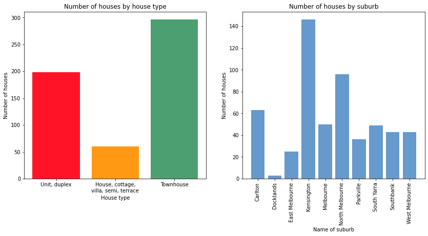

We clearly have more datapoints for certain neighborhoods and house types, but we don't know for sure if its data bias or not. A quick Google [search](https://en.wikipedia.org/wiki/Docklands,_Victoria) tells us that Docklands is an industrial area that was abandoned until 20 years ago and now has apartments for rent. A low number of house sales given this background makes sense! We're working with a relatively narrow time range, but let's see if temporal patterns reveal anything interesting. Take a look at this graph of prices over time.

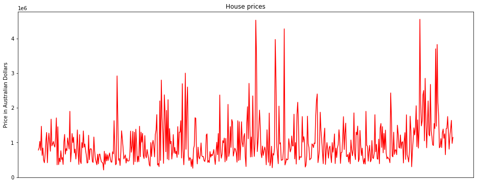

There seems to be a slight increase over time (with a few crazy mansion sales), but inflation is an easy explanation for this (i.e. real house prices in this time frame haven't changed much). What about looking at it on the map? *make sure to press play to see trends over time!*

Make this Notebook Trusted to load map: File -> Trust Notebook

[interactive chart not shown]

Next let's compare prices across the neighborhoods:

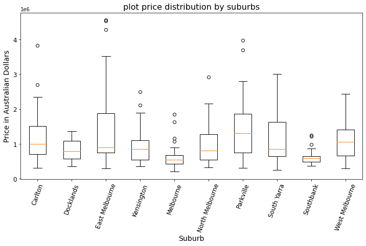

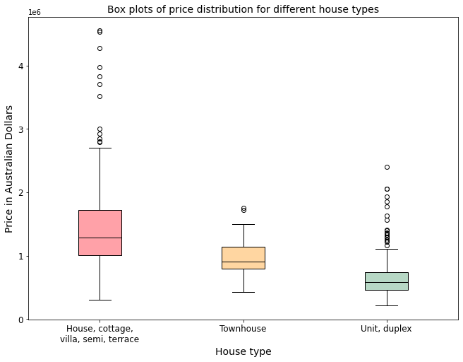

Pretty wide spreads for all of them, but single family homes trending higher. Makes sense so far!

We don't want to be naive and assume all of our data is perfect. Let's take a look at the 'Distance' property provided by our dataset. Experiment with the toggles and see if you can find anything weird.

Make this Notebook Trusted to load map: File -> Trust Notebook

[interactive chart not shown]

You probably noticed that entire neighborhoods have the exact same distance value! Neighborhoods can be pretty widespread, so assigning a uniform value with potential error of ~50% isn't super helpful. Even worse, you may have noticed that houses in central Melbourne fall under both the 0km and 2.8km marker. Clearly this feature is unreliable! We won't be using the distance property.

Let's see where homes are in relation to the green spaces. Hover over the map to see the different neighborhoods.

Make this Notebook Trusted to load map: File -> Trust Notebook

[interactive chart not shown]

The (very aptly named) Parkville clearly has a high density of trees and is lined with homes as well. Otherwise, high levels of trees doesn't seem to indicate high number of home sales (nor is the inverse shown). This can indicate that trees aren't a significant factor when it comes to home sales. Maybe access to water ways, business districts, or highways is more important?

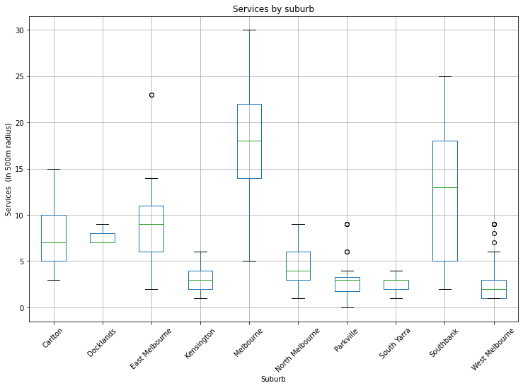

Make this Notebook Trusted to load map: File -> Trust Notebook

[interactive chart not shown]

A little overwhelming to look at, but landmarks/places of interest are definitely located near the houses. What kinds of landmarks does this dataset have?

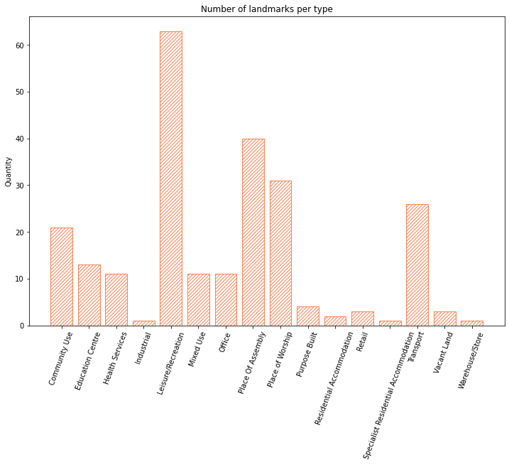

Lots of recreation, places of worship, and transportation. Again makes sense given our spatial distribution.